# Ordered Choice Logit Model for Career Satisfaction of Programmers in Eastern Europe

Jorge Bueno Perez & Lashari Gochiashvili

```r
library(dplyr)
library(knitr)
library(psych)
library(MASS)
library(lmtest)
library(oglmx)
library(generalhoslem)
library(jtools)
library(brant)
library(DescTools)
library(pscl)
library(stargazer)
```

# 1) Abstract:

This paper uses ordered choices logit model to build a model for career satisfaction of programmers in Eastern European countries. The data is based on the online survey results collected by `StackOverlFlow.com`[^1]. The latter is one of the most popular online communities for programmers in the world. In this paper, we explained dependent variable career satisfaction with different independent variables that was selected using ordered choices logit model and verified by statistical tests. To build the econometric model, we used available packages in R such as `MASS`, `lmtest` and `oglmx`. The end result is a final model with significant variables that best explains the career satisfaction of programmers in Eastern Europe.

**Keywords:** career satisfaction, ordered choices logit model, ordered logit model, polr, ologit.reg, lmtest, anova

# 2) Introduction:

> “The only way to do great work is to love what you do. If you haven’t found it yet, keep looking. Don’t settle.”

> — Steve Jobs

Today, it is very important for the organizations to stay competitive on the market. To sustain competitive advantage, organizations need to attract and keep highly talented people. Many companies are trying to be number one choice for the employees on the market. In general, career satisfaction is very much connected to life satisfaction (Joo and Park 2009)[^2].

Growing demand on IT professionals has increased salaries. Companies are trying to study psychological aspects of employees to design strategies how to keep highly talented people in the company and assure their career satisfaction. Career satisfaction leads employees to high job performance. On the other hand, companies are trying to achieve lower levels of turnover (Irvine and Evans,1995)[^3].

In our study we used data collected by `Stack Overflow` during the annual survey in 2018 designed for programmers. `Stack Overflow` is a community forum for programmers. In this forum the users are able to ask questions about their programs, and one is able to reply to them sharing his knowledge.

We will verify the following hypothesis using ordered choices logit model:

**Hypothesis 1:** Higher salary increases career satisfaction In our study we will examine the relationship between salary and career satisfaction. During the career, a person changes the job from one company to another when there is a better offer. Biggest part of the offer is salary levels. When a person is satisfied with the salary, stays in the company longer and claims that she has a higher level of career satisfaction.

**Hypothesis 2:** Having hobby increases career satisfaction We will describe the relationship between having hobby and career satisfaction. We think the people with hobbies are more satisfied with their career and find time to express themselves by having hobbies. Also, people who do not have hobbies are more concerned first to reach career satisfaction and then take some time for hobbies.

# 3) Literature review:

There are many researches conducted to study career satisfaction and the variables that are influencing it. Factors that affect career satisfaction vary, such as education (Andres and Henry 1963)[^4], age (Lawler and Porter 1966)[^5], pay and gender (Mason 1997)[^6].

At a personal, level career satisfaction is defined if a person has meaningful accomplishments in career (Judge et al., 1995)[^7]. Goal orientation is also one of the influential factor in performance and career satisfaction (Kozlowski et al., 2001)[^8]. Career satisfaction is related to job satisfaction. There are many jobs that a person can take during their career. The current job satisfaction is very much related to general career satisfaction. Individuals who have higher level of job satisfaction have better job performance, they are less likely to leave the company and they are committed more to the company than those who have low level of job satisfaction (Fried and Ferris 1987)[^9]. On the other hand, the problem about employee turnover is always actual and requires well established HR strategies by the companies (Joo and McLean 2006)[^10].

Interesting conclusions are derived from the study conducted by Nan Hu and the team[^11]. The is an empirical investigation on how different factors affect job satisfaction for information technology professionals. IT professionals are more likely to be satisfied with their job when the job opportunity is aligned with their career expectations (Hu et al., 2004)[^12]. In our study we will also examine the relationship between career satisfaction and programmers current job satisfaction. Also, IT professionals are more likely to be happy with their job when they have decision power and are given chances to influence with recommendations. However, we will not include these factors in our model as we lack information about these factors. It is worth mentioning that there are some job duties that are demotivating IT professionals (Hu et al., 2004)[^13].

LeDuc broadly overviews “motivation of progammers” in his paper. He groups motivation into two groups `internal` and `external` motivation. `Internal` motivation has to do with person’s needs and satisfiers. The `external` motivation is mostly related to work environmet (LeDuc 1980)[^14]. In their studies, Couger and Zawacki reviewed programmers motivation in different dimensions. In particular, they discussed importance of variety of skills in relation with job satisfaction. What is the role of tasks significance and autonomy in responsibilities and how they related to programmers satisfaction. Study incorporates many psychological aspects and analyzes Maslow’s hierarchy of need connected to the motivation and satisfaction of programmers at their jobs (Couger and Zawacki 1978)[^15].

# 4) Data description:

`Stack Overflow` is a community forum for programmers. In this forum the users are able to ask questions about their programs, and one is able to reply to them sharing his knowledge.

[1] “The dataset survey initialy has 88883 rows and 85 columns”

- More details about `Stack Overflow`: https://stackoverflow.com/company
- Next it can be found the link to the data in `kaggle`: https://www.kaggle.com/stackoverflow/stack-overflow-2018-developer-survey

## 4.1) Data preparation:

During the process of cleaning the data several strategies were applied.

First of all, we `selected several columns`, based on our `intuition`, trying to answer the following question `“Which questions of the survey can explain the best the career satisfaction of the programmers?”.`

`Eight survey questions were selected`, together with the dependent variable of our model – `CareerSatisfaction`. More details about the questions can be found below, linked to the columns of our data:

- `CareerSatisfaction` – Overall, how satisfied are you with your career thus far?
- `Country` - In which country do you currently reside?
- `FormalEducation` - Which of the following best describes the highest level of formal education that you have completed?
- `CompanySize` - Approximately how many people are employed by the company or organization you work for?
- `YearsCoding` - For how many years have you coded professionally (as a part of your work)?
- `JobSatisfaction` – How satisfied are you with your current job? If you work more than one job, please answer regarding the one you spend the most hours on.
- `ConvertedSalary` – What is your current gross salary (before taxes and deductions)? Please enter a whole number in the box below, without any punctuation. If you are paid hourly, please estimate an equivalent weekly, monthly, or yearly salary. If you prefer not to answer, please leave the box empty. *NOTE: (There was an option to select the currency. After, the salary was converted to annual USD salaries using the exchange rate on 2018-01-18, assuming 12 working months and 50 working weeks)
- `Hobby` - Do you code as a hobby?
- `Age` - What is your age? If you prefer not to answer, you may leave this question blank.

```r
survey <- survey %>%
  dplyr::select(CareerSat, Country, EdLevel,
                OrgSize, YearsCode, JobSat,
                ConvertedComp, Hobbyist, Age) # the column names are different from 2018 survey
```

```r
colnames(survey) <- c('CareerSatisfaction', 'Country', 'FormalEducation',
                'CompanySize', 'YearsCoding', 'JobSatisfaction',
                'ConvertedSalary', 'Hobby', 'Age') # changed as per the same names of 2018 survey
```

In some questions the respondents had the option to not reply, having the option to leave in blank some of them. For this reason, we `excluded the missing value and nulls`, consequently we assume that `programmers are people who are employed and receive salary`. This assumption was motivated by the empty values in the columns `ConvertedSalary` and `CompanySize`. Apart from that, we considered `only programmers that gave their Age`.

```r
survey <- survey %>%
  filter(ConvertedSalary!=0) %>%
  na.omit(survey)
```

We will check if there is any `NA` or `zero` values:

```r
any(is.na(survey))
```

[1] FALSE

```r
any(survey$ConvertedSalary <= 0) %>%
  knitr::knit_print()
```

[1] FALSE

Both of the results were `FALSE`, hence we can continue farther.

The next step was to select `ten Eastern countries` to study: `Poland`, `Czech Republic`, `Hungary`, `Slovakia`, `Romania`, `Bulgaria`, `Turkey`, `Moldova`, `Belarus` and `Ukraine`.

```r
survey <- survey %>%
  filter(
    Country %in% c("Poland", "Czech Republic", "Hungary", "Slovakia", "Romania",
      "Bulgaria", "Turkey", "Moldova", "Belarus", "Ukraine"))
```

Subsequently, each variable selected was analyzed separately, in order to find some `outliers` in case of `numeric` variables and to `encode the data` in case of `ordinal` features:

Below more details about the encoding can be found:

- `Disatisfied`: “Extremely dissatisfied”, “Moderately dissatisfied” and “Slightly dissatisfied”, encoded to 1
- `Neutral`: “Neither satisfied nor dissatisfied”, encoded to 2
- `Satisfied`: “Slightly satisfied”, “Moderately satisfied” and “Extremely satisfied”, encoded to 3

[1] “Slightly satisfied” “Very satisfied”  
[3] “Slightly dissatisfied” “Neither satisfied nor dissatisfied” [5] “Very dissatisfied”

```r
survey$CareerSatisfaction <-
  plyr::revalue(
    survey$CareerSatisfaction,
    c("Very dissatisfied" = 1, # changed extremly to very, before there were 7 levels, now just 5
      "Slightly dissatisfied" = 1,

      "Neither satisfied nor dissatisfied" = 2,

      "Slightly satisfied" = 3,
      "Very satisfied" = 3)) %>% as.factor()
```

- `Country`: This `characteristic` feature was previously described. However, after removing missing values there is one country less (Moldova), hence we will have `nine countries`. It `cannot be ordered in a logical way`, hence it will be encoded, but it will be transformed to `factor`.

[1] “Czech Republic” “Poland” “Turkey” “Romania”  
[5] “Bulgaria” “Hungary” “Ukraine” “Slovakia”  
[9] “Belarus”

```r
survey$Country <- survey$Country %>%
  as.factor()
```

- `FormalEducation` - This `characteristic` feature has `nine levels` that `can be ordered in a logical way`, from “I never completed any formal education”, to “Other doctoral degree (Ph.D, Ed.D., etc.)”.

Because this feature can be `ordered in a logical way`, it will be grouped in three categories:

- `Low level of education`: “I never completed any formal education”, “Primary/elementary school” and “Secondary school (e.g. American high school, German Realschule or Gymnasium, etc.)”, encoded to 1
- `Medium level of education`: “Professional degree (JD, MD, etc.)”, “Some college/university study without earning a degree” and “Associate degree”, encoded to 2
- `High level of education`: “Bachelor’s degree (BA, BS, B.Eng., etc.)”, “Master’s degree (MA, MS, M.Eng., MBA, etc.)” and “Other doctoral degree (Ph.D, Ed.D., etc.)”, encoded to 3

Below more details about the encoding can be found:

[1] “Master’s degree (MA, MS, M.Eng., MBA, etc.)”  
[2] “Some college/university study without earning a degree”  
[3] “Bachelor’s degree (BA, BS, B.Eng., etc.)”  
[4] “Secondary school (e.g. American high school, German Realschule or Gymnasium, etc.)” [5] “Other doctoral degree (Ph.D, Ed.D., etc.)”  
[6] “Associate degree”  
[7] “Primary/elementary school”  
[8] “I never completed any formal education”  
[9] “Professional degree (JD, MD, etc.)”

```r
survey$FormalEducation <- plyr::revalue(
  survey$FormalEducation,
  c(
    "I never completed any formal education" = 1,
    "Primary/elementary school" = 1,
    "Secondary school (e.g. American high school, German Realschule or Gymnasium, etc.)" = 1,

    "Professional degree (JD, MD, etc.)" = 2,
    "Some college/university study without earning a degree"  = 2,
    "Associate degree" = 2,

    "Bachelor’s degree (BA, BS, B.Eng., etc.)"  = 3,
    "Master’s degree (MA, MS, M.Eng., MBA, etc.)" = 3,
    "Other doctoral degree (Ph.D, Ed.D., etc.)" = 3
  )
) %>%
  as.factor() # it states the same
```

Because this feature can be `ordered in a logical way`, it will be grouped in three categories:

- `Small company size`: “Fewer than 10 employees”, “10 to 19 employees” and “20 to 99 employees”, encoded to 1
- `Medium company size`: “100 to 499 employees” and “500 to 999 employees”, encoded to 2
- `Big comopany size`: “1,000 to 4,999 employees”, “5,000 to 9,999 employees” and “10,000 or more employees”, encoded to 3

Below more details about the encoding can be found:

[1] “10 to 19 employees”  
[2] “20 to 99 employees”  
[3] “1,000 to 4,999 employees”  
[4] “5,000 to 9,999 employees”  
[5] “100 to 499 employees”  
[6] “10,000 or more employees”  
[7] “2-9 employees”  
[8] “500 to 999 employees”  
[9] “Just me - I am a freelancer, sole proprietor, etc.”

```r
survey$CompanySize <- plyr::revalue(
  survey$CompanySize,
  c(
    "2-9 employees" = 1, # changed from "Fewer than 10 employees" to "2-9 employees"
    "10 to 19 employees" = 1,
    "20 to 99 employees" = 1,

    "100 to 499 employees" = 2,
    "500 to 999 employees" = 2,

    "1,000 to 4,999 employees"  = 3,
    "5,000 to 9,999 employees" = 3,
    "10,000 or more employees"  = 3

    )) %>% as.factor()
```

Below more details about the encoding can be found:

[1] “30” “12” “5” “6”  
[5] “16” “3” “11” “8”  
[9] “20” “27” “32” “4”  
[13] “28” “13” “15” “10”  
[17] “25” “18” “9” “1”  
[21] “19” “21” “14” “40”  
[25] “2” “22” “7” “24”  
[29] “35” “Less than 1 year” “23” “26”  
[33] “33” “17” “29” “34”  
[37] “36” “31” “37”

```r
survey$YearsCoding[survey$YearsCoding == "Less than 1 year"] <- 1
survey$YearsCoding[survey$YearsCoding %in% (3:5)] <- 1

survey$YearsCoding[survey$YearsCoding %in% (6:17)] <- 2

survey$YearsCoding[survey$YearsCoding %in% (18:50)] <- 3
```

Because this feature can be `ordered in a logical way`, it will be grouped in three categories:

- `Disatisfied`: “Extremely dissatisfied”, “Moderately dissatisfied” and “Slightly dissatisfied”, encoded to 1
- `Neutral`: “Neither satisfied nor dissatisfied”, encoded to 2
- `Satisfied`: “Slightly satisfied”, “Moderately satisfied” and “Extremely satisfied”, encoded to 3

Below more details about the encoding can be found:

[1] “Very satisfied” “Slightly satisfied”  
[3] “Slightly dissatisfied” “Neither satisfied nor dissatisfied” [5] “Very dissatisfied”

```r
survey$JobSatisfaction <- # same change as CareerSatisfaction
  plyr::revalue(
    survey$JobSatisfaction,
    c("Very dissatisfied" = 1, # changed extremly to very, before there were 7 levels, now just 5
      "Slightly dissatisfied" = 1,

      "Neither satisfied nor dissatisfied" = 2,

      "Slightly satisfied" = 3,
      "Very satisfied" = 3)) %>% as.factor()
```

Below we can find a `scatter plot` of this feature, in `red` we can find the `cutoff point`:

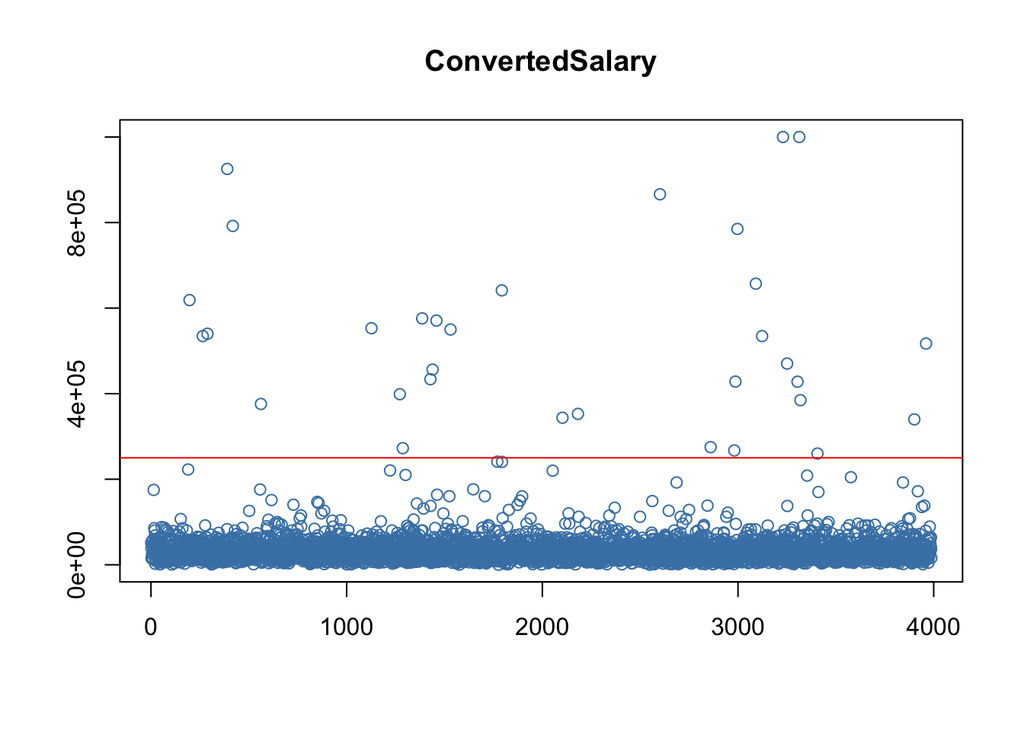

We can find below the amount of observation which `ConvertedSalary` is greater than the `cutoff point`:

```r
survey %>%
  filter(survey$ConvertedSalary > 250000) %>%
  nrow() %>%
  knitr::knit_print()
```

[1] 32

```r
survey <- survey %>%
  filter(survey$ConvertedSalary < 250000)
```

```r
survey$ConvertedSalary <- survey$ConvertedSalary / 1000
```

- `Hobby` - This `characteristic binomial` feature, “Yes” or “No”, was respectively transformed to “1” and “0”.

[1] “Yes” “No”

```r
survey$Hobby <-
  plyr::revalue(survey$Hobby,
                c("No" = 0,
                  "Yes" = 1)) %>% as.factor()
```

Below can be found more details about the encoding:

[1] 44.0 22.0 25.0 24.0 34.0 36.0 30.0 28.0 29.0 35.0 47.0 37.0 48.0 23.0 40.0 [16] 31.0 32.0 38.0 39.0 33.0 27.0 26.0 41.0 42.0 52.0 21.0 45.0 19.0 20.0 18.0 [31] 50.0 49.0 43.0 17.0 53.0 46.0 58.0 56.0 61.0 62.0 59.0 51.0 55.0 33.6 16.0 [46] 54.0 23.5 2.0 63.0

```r
survey$Age <- survey$Age %>%
  as.integer()

survey$Age[survey$Age %in% (0:24)] <- 1

survey$Age[survey$Age %in% (25:44)] <- 2

survey$Age[survey$Age %in% (45:100)] <- 3

survey$Age <- survey$Age %>%
  as.factor()
```

As we saw above, the `characteristics` features were transformed `to factors`.

[1] “The dataset survey after the preparation has 3956 rows and 9 columns”

Finally, we will change the names of the columns, in order to remove the capital letters:

```r
colnames(survey) <- c("career.satisfaction", "country", "education", "company.size", "years.coding", "job.satisfaction", "salary", "hobby", "age")
```

## 4.2) Data representation:

Below there is a `summary` of the dataset:

|  | vars | n | mean | sd | median | trimmed | mad | min | max | range | skew | kurtosis | se |
| --- | --- | --- | --- | --- | --- | --- | --- | --- | --- | --- | --- | --- | --- |
| career.satisfaction* | 1 | 3956 | 2.58 | 0.75 | 3.0 | 2.72 | 0.00 | 1.00 | 3.00 | 2.00 | -1.40 | 0.26 | 0.01 |
| country* | 2 | 3956 | 5.32 | 2.26 | 5.0 | 5.31 | 2.97 | 1.00 | 9.00 | 8.00 | 0.12 | -0.87 | 0.04 |
| education* | 3 | 3956 | 2.64 | 0.65 | 3.0 | 2.80 | 0.00 | 1.00 | 3.00 | 2.00 | -1.60 | 1.15 | 0.01 |
| company.size* | 4 | 3956 | 1.92 | 0.93 | 2.0 | 1.84 | 1.48 | 1.00 | 4.00 | 3.00 | 0.50 | -0.98 | 0.01 |
| years.coding* | 5 | 3956 | 1.97 | 0.60 | 2.0 | 1.96 | 0.00 | 1.00 | 3.00 | 2.00 | 0.01 | -0.20 | 0.01 |
| job.satisfaction* | 6 | 3956 | 2.42 | 0.83 | 3.0 | 2.52 | 0.00 | 1.00 | 3.00 | 2.00 | -0.90 | -0.95 | 0.01 |
| salary | 7 | 3956 | 33.25 | 23.99 | 28.8 | 30.23 | 18.93 | 0.02 | 240.95 | 240.93 | 2.45 | 11.89 | 0.38 |
| hobby* | 8 | 3956 | 1.80 | 0.40 | 2.0 | 1.88 | 0.00 | 1.00 | 2.00 | 1.00 | -1.51 | 0.29 | 0.01 |
| age* | 9 | 3956 | 1.82 | 0.44 | 2.0 | 1.87 | 0.00 | 1.00 | 3.00 | 2.00 | -0.83 | 0.63 | 0.01 |

*NOTE: The features with asterik are `factors`.

In the next graph we can find the `distribution by levels` of the dependent variable.

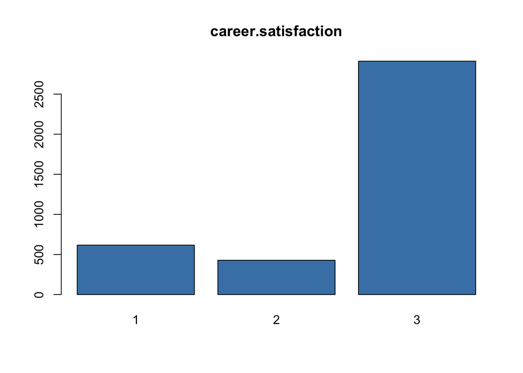

As we can observe the data is `imbalanced`. There are much more people with the level 3 `satisfied` than the other levels, 1 `disatisfied` and 2 `neutral`.

Below we can find a representation of the `covariates`:

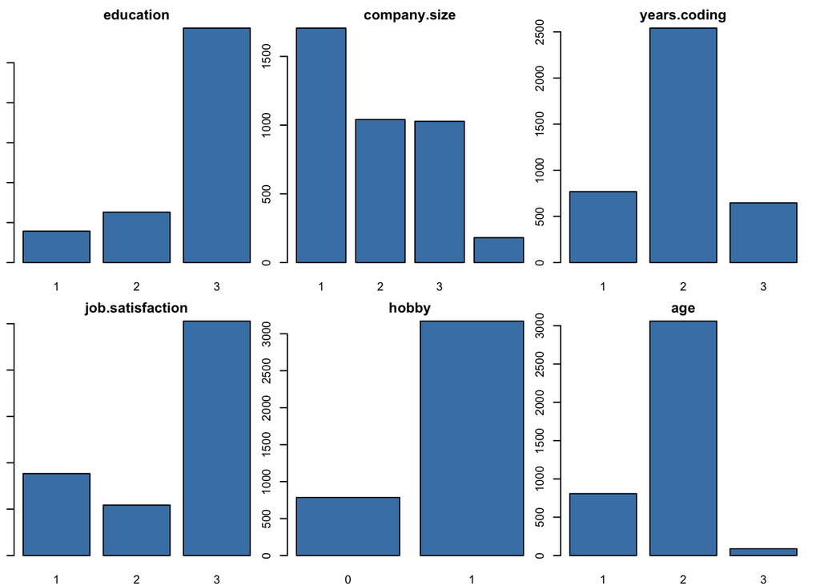

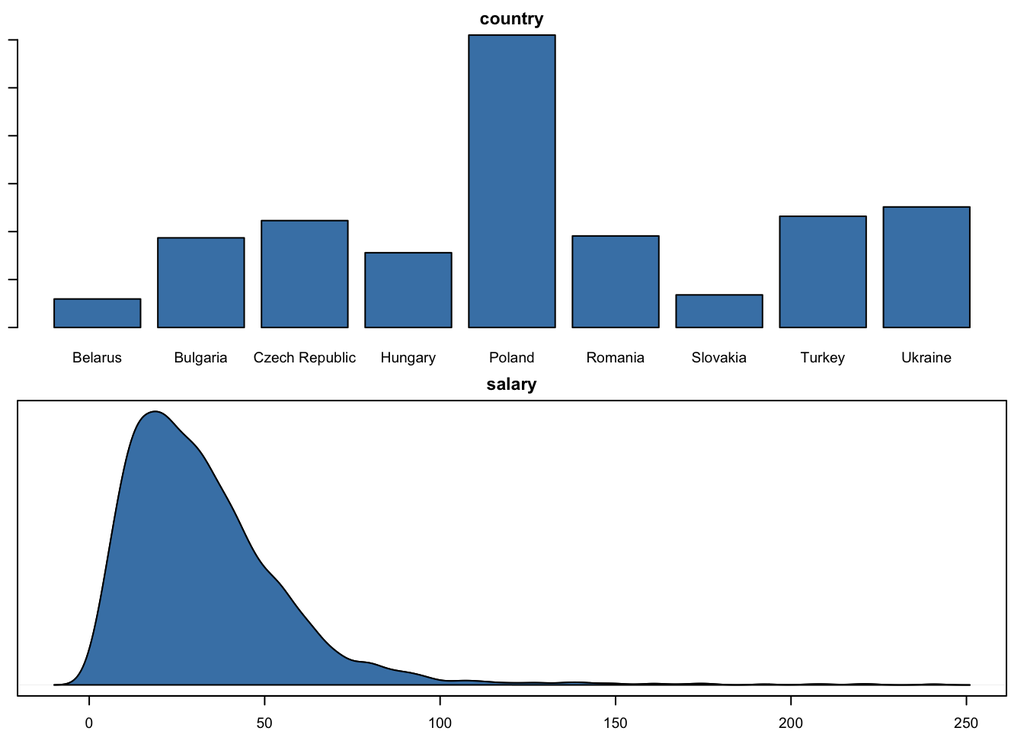